# MATH5741M: Statistical Theory and Methods Lecture 1

27 September, 2021  
Reminder to myself: start recording and let people out of the waiting room.

## Timetable

The timetable is currently uncertain, but this is what we expect:

- Live face-to-face lecture/workshop, Monday 10am on odd weeks.
- Live face-to-face computer classes, Thursday 9am every week.

Outside of our live lessons, you are expected to spend a few hours (maybe about four or five) each week reading lecture notes and watching videos on Minerva.

The remaining time for this module each week should be spent working on homework exercises and on your coursework assignment.

**If any of you need to remain online, please email me as soon as possible.**

## Who am I?

- PhD and MMath in Pure Maths from Durham.
- Research Associate in Statistics at Durham.
- Research Methods Fellow at the Leeds Institute for Clinical Trials Research.
- Associate Lecturer of Statistics at York.
- Permanent Teaching Fellow in the Leeds School of Mathematics.

## Statistics and data science

“The unique strength of the statistics discipline is the extent of its relevance to the whole of the natural and social sciences.”

[Peter Diggle, Statistics: a data science for the 21st century](https://rss.onlinelibrary.wiley.com/doi/10.1111/rssa.12132)

“I do think it would be fair to consider statistics as a subset of data science. The tech industry has always had to deal with databases and coding… The statistical part of data science is more of an option.”

[Andrew Gelman, Columbia University (statmodeling.stat.columbia.edu)](https://statmodeling.stat.columbia.edu/2013/11/14/statistics-least-important-part-data-science/)

“If data science is a close relation of statistics, its increasing popularity must surely present us [statisticians] with an opportunity… What can we offer? Crucially, we can assert that uncertainty is ubiquitous and that probability is the correct way to deal with uncertainty. We understand the uncertainty in our data by building stochastic models, and in our conclusions by probabilistic inference.”

[Peter Diggle, Statistics: a data science for the 21st century](https://rss.onlinelibrary.wiley.com/doi/10.1111/rssa.12132)

## Motivating examples

I will always motivate any difficult theory in this module using examples based on real research. I strongly believe that giving theory without context is just a poor method of teaching.

Medical examples are particularly inspiring and will be common throughout this module.

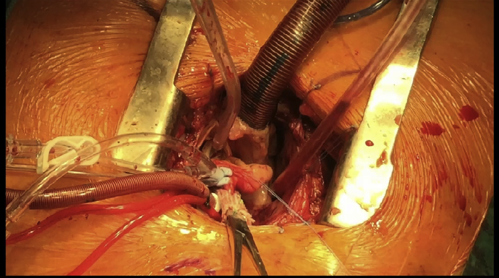

Photograph of an aortic valve replacement form the MiniStern clinical trial (https://www.ncbi.nlm.nih.gov/pubmed/30075959). Statistical analysis of this trial was carried out here in Leeds, at the Clinical Trials Research Unit.

## Motivating examples

Another example that we will use frequently is based on **real** astronomy data.[Harris WE, et al. 2013. A catalog of globular cluster systems: what determines the size of a galaxy’s globular cluster population?. Astrophysical Journal **772** (2).](https://iopscience.iop.org/article/10.1088/0004-637X/772/2/82/meta)

```r
galaxies[1:10, ]
```

```r
#    Galaxy GlobularClusters BlackHoleMass  Distance Vdispersion Eradius       Type
#  MilkyWay              160          6.61         0       105.0    2300     Spiral
#    NGC221                0          6.46   2500000        75.0     400 Elliptical
#    NGC224              450          8.18   2500000       160.0   15200     Spiral
#    NGC253               90          7.00  11500000       102.6   12400     Spiral
#    NGC821              320          8.23  76200000       209.0   18400 Elliptical
#   NGC1023              490          7.64  37300000       209.0    7100     Spiral
#   NGC1316             1000          8.24  68800000       227.7   33200 Lenticular
#   NGC1332             1000          9.17  74700000       320.9    9000 Lenticular
#   NGC1399             6000          8.69  67400000       337.0   31600 Elliptical
#   NGC2778               50          7.15  74700000       175.0    5700 Elliptical
```

## Motivating examples

- `GlobularClusters`, the number of globular star clusters orbiting the the core of the galaxy.
- `BlackHoleMass`, the mass of the black hole at the centre of the galaxy.
- `Distance`, the distance from Earth in light-years.
- `Vdispersion`, how fast objects in the galaxy are moving relative to each other.
- `Eradius`, the radius at which half of the total light of the galaxy is emitted.
- `Type`: Elliptical, Spiral or Lenticular.

[figure not shown]

The Milky Way galaxy. Credit: ESA/Hubble, NASA, L Calcada, M Kormesser.

## Motivating examples

But why do **we** care about this? Isn’t this a job for an astronomer?

“Revealing hidden patterns in astronomical data is often the path to fundamental scientific breakthroughs; meanwhile the complexity of scientific enquiry increases as more subtle relationships are sought. Contemporary data analysis problems often elude the capabilities of classical statistical techniques, suggesting the use of cutting edge statistical methods.”

[Rafael S. de Souza, et al. The overlooked potential of GLMs in astronomy.](https://www.sciencedirect.com/science/article/abs/pii/S2213133715000360)

## Coursework

Your coursework is based on data from the [Radford/FGCU Serial Killer database](http://maamodt.asp.radford.edu/Serial%20Killer%20Information%20Center/Project%20Description.htm).

But, again, why do **we** care about this? Isn’t this a job for a criminologist?

It has been noted that, generally, research on serial killers has limited credibility and relies too heavily on case studies and descriptive statistics.[Gurian EA. 2017. Reframing serial murder within empirical research. International Journal of Offender Therapy and Comparative Criminology **61**(5).](https://journals.sagepub.com/doi/abs/10.1177/0306624X15598572)

Recently published research on serial killers[Simkin MV, Roychowdhury VP. 2014. Stochastic modeling of a serial killer. Journal of Theoretical Biology **355**.](https://arxiv.org/abs/1201.2458) has received harsh criticism for poor use of statistics and for its attempt to link epilepsy to criminal behaviour.

```r
load("killersandmotives.Rdata")
```

```r
x = 16   # a number that I will allocate to you
```

```r
createsample(x)   # this function takes a unique sample of killers for you to analyse
```

## Coursework

```r
mysample   # this is the sample for you to analyse
```

```r
# AgeFirstKill AgeLastKill YearBorn              Motive     Sex   Race          Sentence
#           25          25     1962      Angel of Death  Female  White              Life
#           39          39     1956      Angel of Death  Female  White              Life
#           51          51     1943      Angel of Death  Female  White    Not prosecuted
#           19          26     1946  Enjoyment or power    Male  White              Life
#           38          40     1958  Enjoyment or power    Male  White     Death penalty
#           18          19     1957  Enjoyment or power    Male  White              Life
#           31          31     1962  Enjoyment or power    Male  White     Death penalty
#           36          38     1966  Enjoyment or power  Female  White              Life
#           25          25     1986  Enjoyment or power    Male  Black Died before trial
#           45          48     1944  Enjoyment or power    Male  White     Death penalty
#           18          23     1968  Enjoyment or power    Male  Black              Life
```

There are detailed instructions in the **Coursework** document on the Minerva page. You are expected to work on this coursework **continuously throughout the semester**.

## Questions

Do you have any questions or comments about any part of the module? For example, teaching, feedback, assessment or Minerva.

## Tasks

**Before this week’s** practical (Thursday), please install R and RStudio on your computer.

**Before next week** you should:

- Read **all** of Chapter 1 and Chapter 2 of the lecture notes.
- Watch the short videos for Chapters 1 and 2.
- Think about who you would like to have in your group for the coursework (usually 4 or 5 students).
- There is **no** homework assignment this week.